# Spatial Upscalling

Flueckiger_Rubens

2025-11-24

# 1 Introduction

Cross validation (CV) is an important feature in machine learning to optimise target prediction. However, a lack of sufficiently spatially covered observation data yields a big problem for accurately predicting a target variable in a observation-sparse region. In this report exercise, I will compare three different methods of splitting training data in n different folds to tackle the previous mentioned problem. First, CV-folds will be generated by randomly splitting training data in 5 folds. Secondly, I will split the training data into 5 regions according to the observations geographical location. These splits will be used to perform a 5-fold CV. Finally, I will split the training data into 5 classes according to the predictors temperature and precipitation value to perform a 5-fold CV. For each CV $R^2$ and Root mean square error ($RMSE$) value will be returned to compare the results with each other.

# 2 Literature analysis

Given the paper of Ludwig et al. ([2023](https://doi.org/10.1111/geb.13635)) we will first answer the following questions; What is the difference between a *random* and a *spatial* CV, and could one use a different metric other than the euclidean distance metric used in the paper to group observations into different classes.

## 2.1 CV differences

A random cross-validation method splits data independent of their location into n training folds; the resulting folds only match in their distribution of predictor variables. This approach lead to variables that can well reproduce clustered training data but might not be well-suited for spatial predictions due to an insufficiently covered training data to predict remote location settings. Spatial cross-validation on the other hand distributes data into different folds according to their geographical location. This approach might mimic a real-world scenario a bit better as it will favour variables that lead to a high ability to make predictions for new areas.

## 2.2 Distance operator

The goal of using a euclidean distance operator to check if a target site is within a certain distance from a observation site to ensure applicability of this target site is given, one does not necessarily need to use a euclidean distance metric as shown in the paper from Ludwig et al. The applicability of the target site can be measured more directly by comparing the predictors of the target site with those of the observations. Doing this comparison one does get a n-dimensional room (with n the number of predictors used to model the target variable) where the distance between the point cloud of the observation sites and the the target site can be used to determine the applicability of the model on the target site. This is not only a more direct but also a more accurate metric of identifying the applicability, as the target is a direct function of the environmental conditions given through the predictors. The longitudinal and latitudinal information of target and observational sites are (only) a indirect function of the target variable (spatial information is a function of environment, which in return is a function of the target variable).

# 3 Packages and data

In a first step, all necessary packages to perform the analysis will be loaded.

```r
library(caret)
library(dplyr)
library(ggplot2)
library(ranger)
library(RColorBrewer)
library(rnaturalearth)
library(rnaturalearthdata)
library(sf)
library(skimr)
library(tidyverse)
```

In a next step we can load the data set. Since the data set will be loaded from the internet, I will store it additionally inside the *data* folder such that the file can be reproduced without internet access. To ensure that the file loading process will not be executed again it will be enclosed within a `if(FALSE){}` statement.

```r
if(FALSE){
  df <- readr::read_csv(
    "https://raw.githubusercontent.com/geco-bern/leafnp_data/main/data/leafnp_tian_et_al.csv")

  # Safe df for offline use
  write.csv(
    df,
    file = "../data/Spatial_Upscalling/leafnp_data", # Location
    row.names = FALSE # Don't save indices
  )
}

df <- readr::read_csv("../data/Spatial_Upscalling/leafnp_data")
```

## 3.1 Data preprocessing

Now we will create a subset of the original data, which only contains the necessary predictors, which are:

- `leafN`: leaf nitrogen content, in mass-based concentration units [$gNgDM^{-1}$]
- `lon`: longitude in decimal degrees east
- `lat`: latitude in decimal degrees north
- `elv`: Elevation above sea level [$m$]
- `mat`: mean annual temperature [$°C$]
- `map`: mean annual precipitation [$mmyr^{-1}$]
- `ndep`: atmospheric nitrogen deposition [$gmyr^{-1}$]
- `mai`: mean annual daily irradiance [$\mu mol m^{-2} s^{-1}$]
- `Species`: species name of the plant on which leaf N was measured

```r
common_species <- df |>
  group_by(Species) |>
  summarise(count = n()) |>
  arrange(desc(count)) |>
  slice(1:50) |>
  pull(Species)

dfs <- df |>
  dplyr::select(leafN, lon, lat, elv, mat, map, ndep, mai, Species) |>
  filter(Species %in% common_species)

# quick overview of data
skimr::skim(dfs)
```

Data summary

| Name | dfs |
| --- | --- |
| Number of rows | 22472 |
| Number of columns | 9 |
| _______________________ |  |
| Column type frequency: |  |
| character | 1 |
| numeric | 8 |
| ________________________ |  |
| Group variables | None |

**Variable type: character**

| skim_variable | n_missing | complete_rate | min | max | empty | n_unique | whitespace |
| --- | --- | --- | --- | --- | --- | --- | --- |
| Species | 0 | 1 | 10 | 23 | 0 | 50 | 0 |

**Variable type: numeric**

| skim_variable | n_missing | complete_rate | mean | sd | p0 | p25 | p50 | p75 | p100 | hist |
| --- | --- | --- | --- | --- | --- | --- | --- | --- | --- | --- |
| leafN | 0 | 1 | 15.58 | 5.11 | 1.02 | 12.22 | 14.57 | 17.50 | 54.04 | ▂▇▂▁▁ |
| lon | 0 | 1 | 18.08 | 27.33 | -157.79 | 5.24 | 13.62 | 19.95 | 140.59 | ▁▁▇▂▁ |
| lat | 0 | 1 | 48.35 | 9.55 | -37.49 | 43.00 | 48.99 | 52.44 | 69.75 | ▁▁▁▆▇ |
| elv | 0 | 1 | 494.28 | 469.48 | -5.00 | 135.00 | 357.00 | 716.00 | 4847.90 | ▇▂▁▁▁ |
| mat | 0 | 1 | 8.80 | 3.76 | -4.88 | 6.97 | 8.64 | 10.30 | 29.96 | ▁▇▅▁▁ |
| map | 0 | 1 | 818.59 | 314.40 | 105.19 | 607.29 | 721.15 | 955.24 | 3641.73 | ▇▅▁▁▁ |
| ndep | 0 | 1 | 1.22 | 0.51 | 0.07 | 0.82 | 1.22 | 1.55 | 2.68 | ▂▅▇▃▁ |
| mai | 0 | 1 | 0.00 | 0.00 | 0.00 | 0.00 | 0.00 | 0.00 | 0.00 | ▅▇▃▁▁ |

# 4 Random CV

Given the data, we will now perform a random cross-validation. To ensure reproducibility, especially for the interpretation later on, I will set a seed.

```r
set.seed(102)
```

I will use the `caret` package to perform the random CV. Thereby we first need to specify the model given the target variable (leaf nitrogen) and predictors (elevation, temperature, precipitation, atmospheric nitrogen content, solar irradiance and leaf nitrogen measured species) and convert the string into a `caret`-readable format using the base R `formula()` function.

```r
# Select predictors
predictors <- c("elv", "mat", "map", "ndep", "mai", "Species")

# Create string with all variables
fun_pred <- paste(
  c("leafN ~", paste(predictors, collapse = " + ")),
  collapse = " "
)

# Convert into a caret-readable string
fun_pred <- formula(fun_pred)
```

With the `carret::train()` function we can now specify the model to be performed. I will use the model function created above combined with the preprocessed data from Chapter 3.1 Data preprocessing. We will choose method as ranger to perform a 5-fold CV. Inside the `tuneGrid()` function we will specify the model parameters. I will set `mtry` to be equal to 3, `min.node.size` to be 12 and the remaining parameters as their default in `ranger` (which is only `splitrule`; default: ‘variance’), as required by the task. To return the values of $R^2$ and $RMSE$, simply using `$resample` will return the wished metrics for each fold.

```r
mod_cv <- train(
  fun_pred, # Model function
  data = dfs, # training set
  method = "ranger", # Random Forest model
  trControl = trainControl(
    method = "cv", # Cross-Validation method
    number = 5 # 5-Fold CV
  ),
  tuneGrid = data.frame(
    .mtry = 3,
    .min.node.size = 12,
    .splitrule = "variance" # Default
  )
)

# Return metrics
stat <- mod_cv$resample[c("Rsquared", "RMSE")]
stat <- stat |> rename( # Rename row names
  "Rsq_ran" = "Rsquared",
  "RMSE_ran" = "RMSE"
) |> round(3) |> mutate( # Round observations
  "Fold" = mod_cv$resample["Resample"]# Fold number
)

stat <- stat[c("Fold", "Rsq_ran", "RMSE_ran")] # Reorder columns

knitr::kable(
  stat,
  align = "lcc",
  caption = "Table 2: R^2 and RMSE values from a random 5-fold CV"
)
```

Table 2: R^2 and RMSE values from a random 5-fold CV

| Fold | Rsq_ran | RMSE_ran |
| --- | --- | --- |
| Fold1 | 0.686 | 3.085 |
| Fold2 | 0.704 | 3.105 |
| Fold3 | 0.706 | 3.021 |
| Fold4 | 0.669 | 3.181 |
| Fold5 | 0.666 | 3.151 |

# 5 Spatial CV

In a next step we will perform a spatial CV using geographical location as the determining factor for splitting training data in 5 different folds.

## 5.1 Observation distribution

First we will analyse the spatial distribution of our observations.

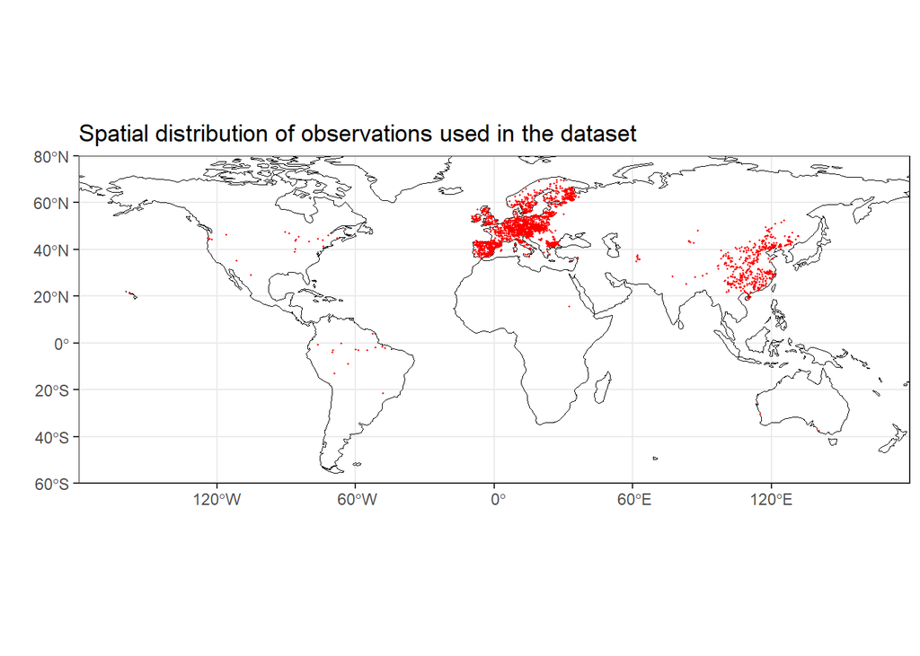

Figure 1: Spatial distribution of every observation of the data set

```r
# get coast outline
coast <- rnaturalearth::ne_coastline(scale = 110, returnclass = "sf")

ggplot() +

  #Plot coastline
  geom_sf(data = coast, colour = "black", size = 0.2) +

  # set extent in longitude and latitude
  # to draw map strictly bounded by the specified extent
  coord_sf(ylim = c(-60, 80), expand = FALSE) +

  # plot points on map
  geom_point(data = dfs, aes(x = lon, y = lat), color = "red", size = 0.2) +

  # Lable adjustments
  labs(
    x = "", y = "",
    title = "Spatial distribution of observations used in the dataset"
  ) +

  theme_bw() +
  theme(legend.position = "bottom")
```

As one can see, observed data is highly concentrated in Europe and China. Informations are extremely sparse everywhere else. This has obvious questions on how reliable the result will be if trained only on Europe and China and applied on regions with no coverage at all (such as Africa for instance).

Nonetheless, China offers a wide range of different environmental conditions, such as dry and cold regions in the north and central, temporal tropical regions in the south and wet temperate climate along the east coast. Even with a few data points a wide range of environmental conditions can be covered by China alone, which will be useful for spatial upscaling.

Nevertheless, desert regions are basically not represented, which thereby means that the results have to be viewed critically.

## 5.2 Spatial classification

To perform a spatial CV, we first need to group the observations. To do so we will use a kmeans unsupervised classifier using 5 centres (which returns 5 classes). To be able to process the data further, I will store the classes within the data frame.

> **Note**

```r
clusters <- kmeans(
  dfs[, c("lon", "lat")], # Lon and lat as clustering parameters
  centers = 5 # 5 clusters
)

# Include class to df. Note: convert into factor format
dfs$class_spat <- as.factor(clusters$cluster)
```

To visualise the resulting clusters we can plot the classes after grouping the observations according to their geographical locations.

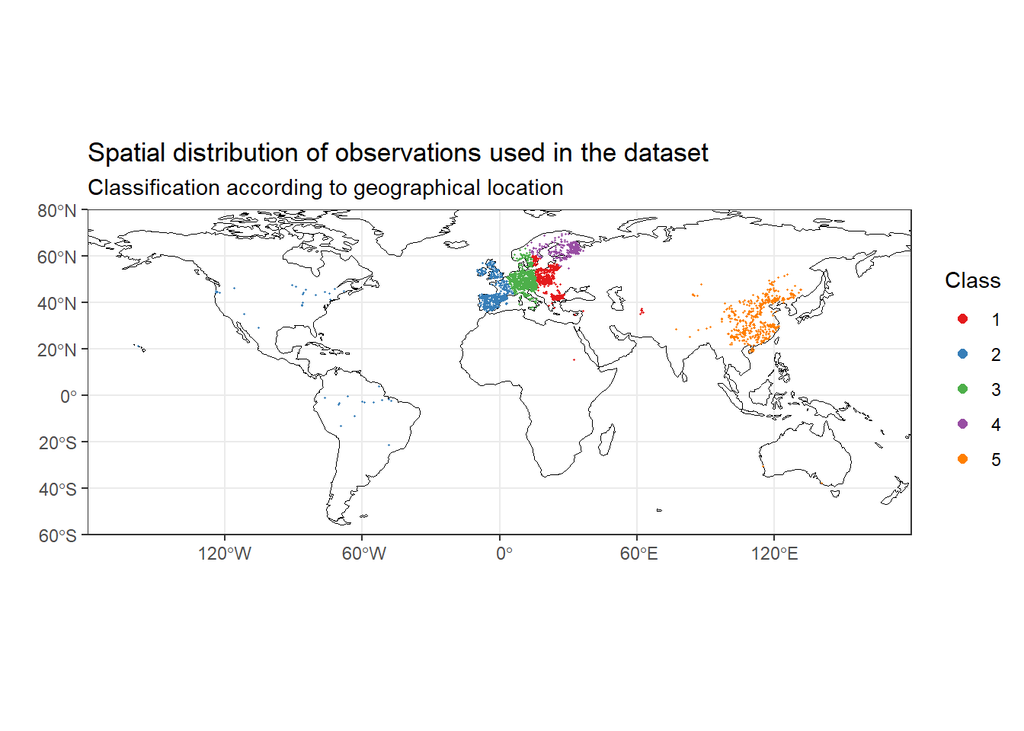

Figure 2: Clusters using a kmeans unsupervised learning model based on geographical locations of the observations form the dataset

```r
ggplot() +

  #Plot coastline
  geom_sf(data = coast, colour = "black", size = 0.2) +

  # set extent in longitude and latitude
  # to draw map strictly bounded by the specified extent
  coord_sf(ylim = c(-60, 80), expand = FALSE) +

  # plot points on map
  geom_point(data = dfs, aes(
    x = lon,
    y = lat,
    colour = class_spat
  ), size = 0.2) +

  # Adjust point size of legend
  guides(color = guide_legend(override.aes = list(size = 2))) +

  # Set colour
  scale_color_manual(name = "Class", values = brewer.pal(n = 5, "Set1")) +

  # Lable adjustments
  labs(
    x = "", y = "",
    title = "Spatial distribution of observations used in the dataset",
    subtitle = "Classification according to geographical location"
  ) +

  theme_bw() +
  theme(legend.position = "right")
```

Following groups can be observed:

- Eastern Europe including western Asia, south eastern Sweden and one observation in Africa
- The American continent including the Iberian peninsula, the UK and the western part of France
- Central Europe including Denmark, south western Sweden and south Norway
- Northern Scandinavia
- China, India and Australia

In addition, we can show the distribution of leaf N over one class using a violin plot and a density curve.

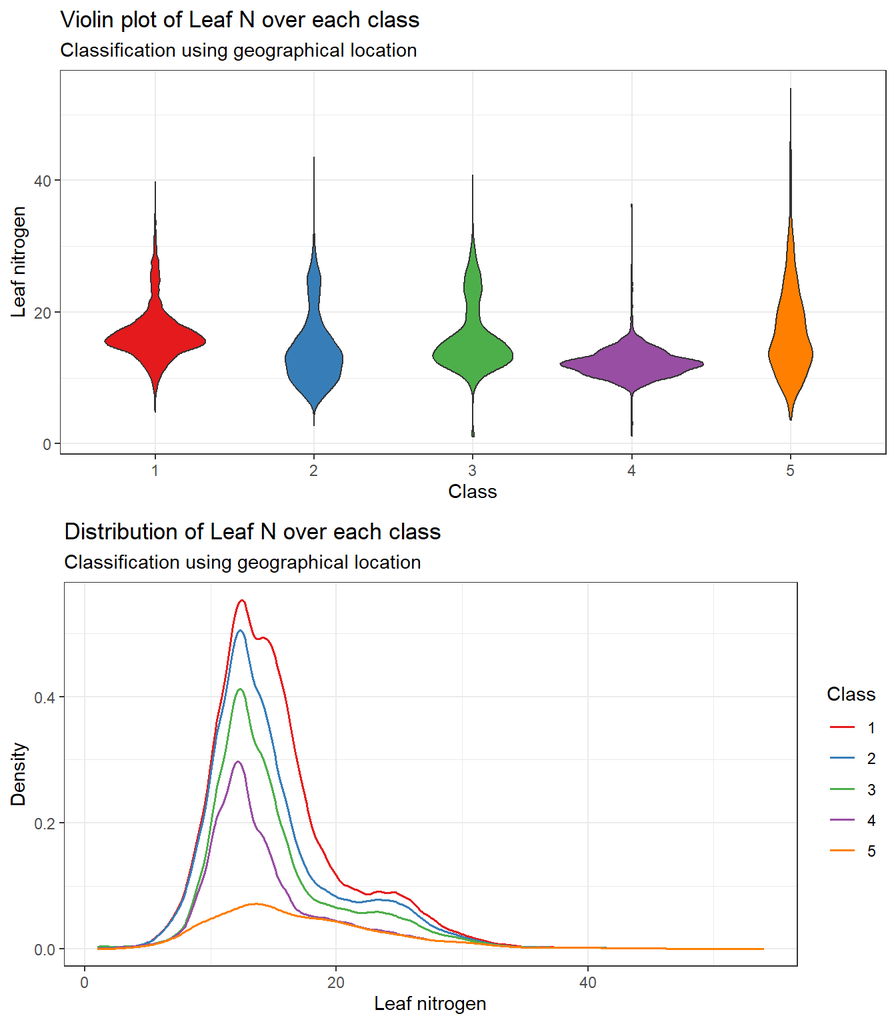

Figure 3: Leaf nitrogen distribution of each class based on spatial classification using a violin plot (top) and a line plot (bottom)

```r
# Distribution using violin plot
p1 <- ggplot(data = dfs, aes(x = class_spat, y = leafN, fill = class_spat)) +
  geom_violin() +

  # Colour plot according to spatial distribution plot
  scale_fill_manual(values = brewer.pal(n = 5, "Set1")) +

  # Adding x & y axis label as well as title
  labs(
    x = "Class",
    y = "Leaf nitrogen",
    title = "Violin plot of Leaf N over each class",
    subtitle = "Classification using geographical location"
  ) +

  theme_bw() +
  theme(legend.position = "") # Remove legend

# Distribution using stat_density
p2 <- ggplot(data = dfs, aes(x = leafN, colour = class_spat)) +
  stat_density(geom = "line", linewidth = 0.7) +

  # Colour plot according spatial distribution
  scale_color_manual(
    values = brewer.pal(n = 5, "Set1"),
    name = "Class"
  ) +

  # Adjust labels
  labs(
    x = "Leaf nitrogen",
    y = "Density",
    title = "Distribution of Leaf N over each class",
    subtitle = "Classification using geographical location"
  ) +

  theme_bw() +
  theme(legend.position = "right")

cowplot::plot_grid(p1, p2, nrow = 2)
```

From the distribution one can see that China, India, Australia class offers the widest range of observations, where as the eastern Europe, western Asia, Africa class and the northern Scandinavia class are heavily concentrated towards a small range of Leaf N values. Class America, Iberian peninsula, UK and class central Europe show very similar distribution with a two-peak distribution (a lower and a higher), where class central Europe shows general higher leaf N values compared to class America Iberian peninsula, UK.

> **Note:**

> Even though I set a seed prior, the class numbers seam to vary randomly from one run-through to the next. I thereby could not use numbers to indicate which class I was characterising.

## 5.3 Function

To extract the $R^2$ and $RMSE$ value from each CV-fold performed, I will first define a function which takes a data frame (the training set), the indices to consider for training and the indices to consider for validating as an input. The function will model the leaf N content given the predictors defined in chapter 4 Random CV and validate the result by applying the generated model on the training set reduced to only contain data with the validation indices. The resulting predicted leaf N will be compared with the observed leaf N from the validation training set and the $R^2$ as well as the $RMSE$ value will be returned.

```r
# create a function that trains a random forest model on a given set of rows and
# predicts on a disjunct set of rows
train_test_by_fold <- function(df, idx_train, idx_val){

  # Split into training and testing set
  df_train <- df[idx_train, ] # training set
  df_test <- df[idx_val, ] # testing set

  # Predictors
  predictors <- c("elv", "mat", "map", "ndep", "mai", "Species")

  mod <- ranger::ranger(
    x = df_train[, predictors],
    y = df_train$leafN,
    min.node.size = 12, # Pre requested from task
    mtry = 3, # Pre requested from task
    splitrule = "variance" # Default from caret::train
  )

  pred <- predict(
    mod, # model
    data = df_test # testing the result
  )

  # Combine obs and pred into 1 df
  df_test$pred <- pred$predictions

  # Calculate RMSE
  rmse <- Metrics::rmse(
    actual = df_test$leafN,
    predicted = df_test$pred
  ) |> round(3)

  # Calculate R2
  rsq <- cor(df_test$leafN, df_test$pred, method = "pearson")^2 |> round(3)

  return(tibble(rsq = rsq, rmse = rmse))
}
```

## 5.4 Modelling

Given the classes derived in chapter 5.2 Spatial classification we can now split the data into a training and testing data for the 5-fold CV. We thereby define the test sets to contain only one class (e.g. class 1) and the training set to contain the remaining classes (e.g. 2 to 5). We will do that for every class available. This operation can be performed using the `purrr::map()` function.

```r
# Return Indices of every class except searched one
group_folds_train <- purrr::map(
  seq(length(unique(dfs$class_spat))), # Amount of classes
  ~ {
    dfs |>
      select(class_spat) |> # Select one class
      mutate(idx = 1:n()) |> # Generate index column
      filter(class_spat != .) |> # Filter for classes which is not currently selected
      pull(idx) # store row index of these classes in idx column
  }
)

# Return indices of searched class
group_folds_test <- purrr::map(
  seq(length(unique(dfs$class_spat))), # Amount of classes
  ~ {
    dfs |>
      select(class_spat) |> # Select one class
      mutate(idx = 1:n()) |> # Generate index column
      filter(class_spat == .) |> # Filter for index of currently selected class
      pull(idx) # Store row index of this class in idx column
  }
)
```

Given the training and testing set we can now apply the function created in chapter 5.3 Function and the function `map2_dfr()` from the `purrr` package to combine $R^2$ and $RMSE$ value output from each CV-fold into one data frame.

```r
out <- purrr::map2_dfr(
  .x = group_folds_train,
  .y = group_folds_test,
  ~ train_test_by_fold(df = dfs, .x, .y) # Function
) |>
  mutate(test_fold = 1:5) # CV fold row
```

To compare the result from the random 5-fold CV of chapter 4 Random CV and the spatial 5-fold CV, we will combine the resulting output in one data frame.

```r
stat <- stat |> mutate( # Add spatial cv metrics
  "Rsq_spat" = out$rsq,
  "RMSE_spat" = out$rmse
)

stat <- stat[c( # Reorder columns
  "Fold",
  "Rsq_ran",
  "Rsq_spat",
  "RMSE_ran",
  "RMSE_spat"
)]

knitr::kable(
  stat,
  align = "lcccc",
  caption = "Table 3: Compareing R^2 and RMSE value from random and spatial 5-fold CV"
)
```

Table 3: Compareing R^2 and RMSE value from random and spatial 5-fold CV

| Fold | Rsq_ran | Rsq_spat | RMSE_ran | RMSE_spat |
| --- | --- | --- | --- | --- |
| Fold1 | 0.686 | 0.513 | 3.085 | 3.121 |
| Fold2 | 0.704 | 0.504 | 3.105 | 3.941 |
| Fold3 | 0.706 | 0.625 | 3.021 | 3.235 |
| Fold4 | 0.669 | 0.180 | 3.181 | 2.247 |
| Fold5 | 0.666 | 0.025 | 3.151 | 7.023 |

# 6 Environmental CV

In a last step we will perform a CV based on environmental conditions.

## 6.1 Environmental classification

Like in chapter 5.2 Spatial classification we will first group the observations based on a metric. However, this time we will use mean annual temperature and mean annual precipitation value to group the observations into 5 different classes. Again I will store the resulting prediction into the original data frame.

> **Note**

```r
clusters <- kmeans(
  dfs[, c(5, 6)], # Lon and lat as clustering parameters
  centers = 5 # 5 clusters
)

# Include class to df. Note: convert into factor format
dfs$class_env <- as.factor(clusters$cluster)
```

To visualise the resulting clusters we can plot the classes after grouping the observations according to their environmental conditions.

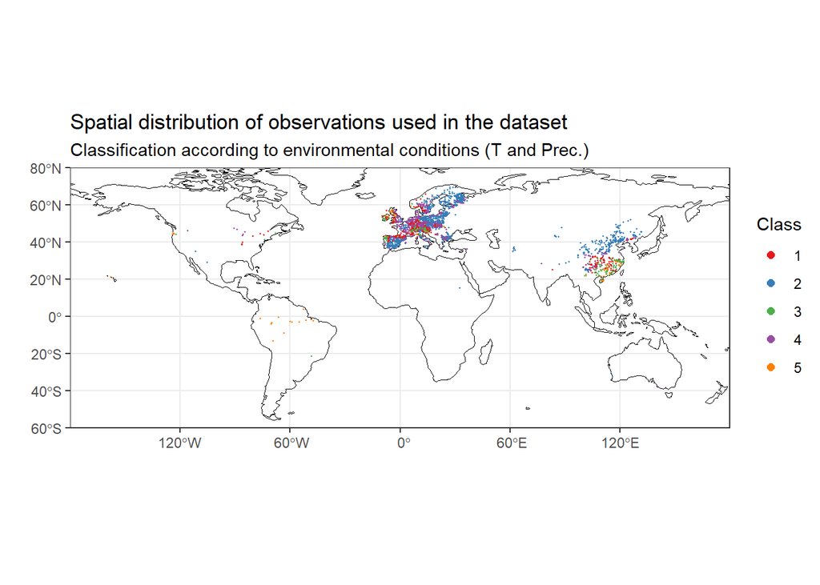

Figure 4: Clusters using a kmeans unsupervised learning model based on mean annual temperature and precipitation of the observations form the dataset

```r
ggplot() +

  #Plot coastline
  geom_sf(data = coast, colour = "black", size = 0.2) +

  # set extent in longitude and latitude
  # to draw map strictly bounded by the specified extent
  coord_sf(ylim = c(-60, 80), expand = FALSE) +

  # plot points on map
  geom_point(data = dfs, aes(
    x = lon,
    y = lat,
    colour = class_env
  ), size = 0.2) +

  # Adjust point size of legend
  guides(color = guide_legend(override.aes = list(size = 2))) +

  # Set colour
  scale_color_manual(name = "Class", values = brewer.pal(n = 5, "Set1")) +

  # Lable adjustments
  labs(
    x = "", y = "",
    title = "Spatial distribution of observations used in the dataset",
    subtitle = "Classification according to environmental conditions (T and Prec.)"
  ) +

  theme_bw() +
  theme(legend.position = "right")
```

To interpret the resulting classifications we need informations about the mean over one class of mean annual temperature and mean annual precipitation. As the training and testing set split will be done later on, I already generated a data frame containing the results.

```r
climate <- readr::read_csv("../data/Spatial_Upscalling/climate_table")

knitr::kable(
  climate,
  align = "lll",
  caption = "Table 4: Mean annual temperature and mean annual precipitation over all observations of a specific class",
  col.names = c("Class", "Average temperature [°C]", "Average precipitation [mm/yr]")
)
```

Table 4: Mean annual temperature and mean annual precipitation over all observations of a specific class

| Class | Average temperature [°C] | Average precipitation [mm/yr] |
| --- | --- | --- |
| 1 | 8.250 | 1058.998 |
| 2 | 8.291 | 578.209 |
| 3 | 7.910 | 1424.812 |
| 4 | 9.837 | 773.238 |
| 5 | 13.055 | 2062.992 |

Following groups can be observed from the table and the plot above:

- Wet mid latitudes: Temperate regions with high precipitation
- Subtropics and boreal zones; dry regions (temperature less important)
- Cold & wet mid latitudes: Cold temperate regions with high precipitation
- Warm & dry mid latitudes: Warm temperate regions with low precipitation
- Tropical; High temperature and precipitation

In addition, we can show the distribution of leaf N over one class using a violin plot and a density curve.

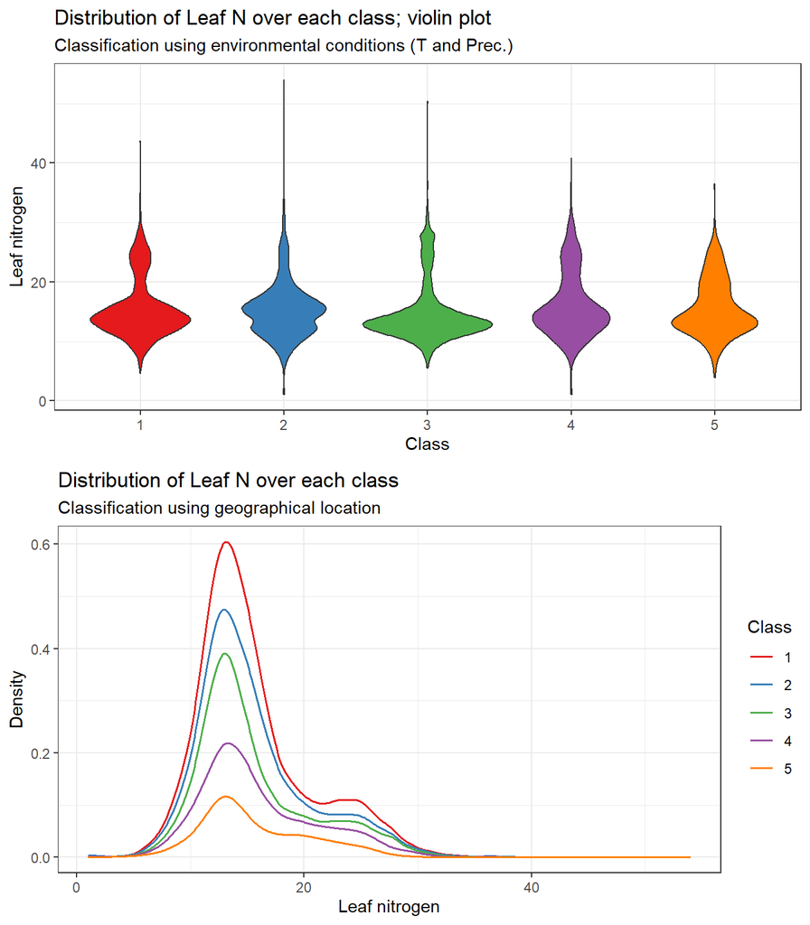

Figure 5: Leaf nitrogen distribution of each class based on environmental classification using a violin plot (top) and a line density plot (bottom)

```r
# Distribution using violin plot
p3 <- ggplot(data = dfs, aes(x = class_env, y = leafN, fill = class_env)) +
  geom_violin() +

  # Colour plot according to environmental distribution plot
  scale_fill_manual(values = brewer.pal(n = 5, "Set1")) +

  # Adding x & y axis label as well as title
  labs(
    x = "Class",
    y = "Leaf nitrogen",
    title = "Distribution of Leaf N over each class; violin plot",
    subtitle = "Classification using environmental conditions (T and Prec.)"
  ) +

  theme_bw() +
  theme(legend.position = "") # Remove legend

# Distribution using stat_density
p4 <- ggplot(data = dfs, aes(x = leafN, colour = class_env)) +
  stat_density(geom = "line", linewidth = 0.7) +

  # Colour plot according spatial distribution
  scale_color_manual(
    values = brewer.pal(n = 5, "Set1"),
    name = "Class"
  ) +

  # Adjust labels
  labs(
    x = "Leaf nitrogen",
    y = "Density",
    title = "Distribution of Leaf N over each class",
    subtitle = "Classification using geographical location"
  ) +

  theme_bw() +
  theme(legend.position = "right")

cowplot::plot_grid(p3, p4, nrow = 2)
```

Except the subtropics and boreal zones class, which has to major maxima pretty close to each other, every class shows a major leaf N concentration with a tail towards higher leaf N concentrations. Class wet mid latitudes shows a major and a minor concentration distribution, where as in class cold and wet mid latitudes show a very strong major leaf N concentration. Class warm and dry mid latitudes and class tropical show a pretty similar distribution.

> **Note:**

> Even though I set a seed prior, the class numbers seam to vary randomly from one run-through to the next. I thereby could not use numbers to indicate which class I was characterising.

## 6.2 Modelling

To perform the modelling step, we first need to split the data set into training and testing set, analogue to chapter 5.4 Modelling.

```r
# Return Index of every class except searched one
group_folds_train_2 <- purrr::map(
  seq(length(unique(dfs$class_env))),
  ~ {
    dfs |>
      select(class_env) |>
      mutate(idx = 1:n()) |>
      filter(class_env != .) |>
      pull(idx)
  }
)

# Return index of searched one
group_folds_test_2 <- purrr::map(
  seq(length(unique(dfs$class_env))),
  ~ {
    dfs |>
      select(class_env) |>
      mutate(idx = 1:n()) |>
      filter(class_env == .) |>
      pull(idx)
  }
)
```

Given the training and testing set we can now apply the function created in chapter 5.3 Function.

```r
out_2 <- purrr::map2_dfr(
  group_folds_train_2,
  group_folds_test_2,
  ~ train_test_by_fold(df = dfs, .x, .y)
) |>
  mutate(test_fold = 1:5)
```

The resulting $R^2$ and $RMSE$ can now be incorporated into the table generated in chapter 5.4 Modelling to make interpretations easier.

```r
stat <- stat |> mutate( # Add spatial cv metrics
  "Rsq_env" = out_2$rsq,
  "RMSE_env" = out_2$rmse
)

stat <- stat[c("Fold", # Reorder columns
  "Rsq_ran",
  "Rsq_spat",
  "Rsq_env",
  "RMSE_ran",
  "RMSE_spat",
  "RMSE_env"
)]

knitr::kable(
  stat,
  align = "lcccccc",
  caption = "Figure 3: Compareing R^2 and RMSE value from random, spatial and environmental 5-fold CV"
)
```

| Fold | Rsq_ran | Rsq_spat | Rsq_env | RMSE_ran | RMSE_spat | RMSE_env |
| --- | --- | --- | --- | --- | --- | --- |
| Fold1 | 0.686 | 0.513 | 0.663 | 3.085 | 3.121 | 2.902 |
| Fold2 | 0.704 | 0.504 | 0.452 | 3.105 | 3.941 | 3.605 |
| Fold3 | 0.706 | 0.625 | 0.618 | 3.021 | 3.235 | 3.121 |
| Fold4 | 0.669 | 0.180 | 0.668 | 3.181 | 2.247 | 3.160 |
| Fold5 | 0.666 | 0.025 | 0.506 | 3.151 | 7.023 | 4.412 |

# 7 Sources

Ludwig, Marvin, Alvaro Moreno-Martinez, Norbert Hölzel, Edzer Pebesma, and Hanna Meyer. 2023. “Assessing and Improving the Transferability of Current Global Spatial Prediction Models.” Global Ecology and Biogeography 32 (3): 356–68. https://doi.org/10.1111/geb.13635